# Country Level Predictor Standardization

Rachel Ledig

4/20/2021

```r
aei_no_std <- read.csv("/Volumes/RachelExternal/Thesis/Data_upload_for_CL/AEI_NoStd.csv")
```

# Standardization

We’ve got a lot of things here to log, scale or center.

What do I mean by scaling or centering?

**Scaling**: Shifting the range of the predictor between [0,1] using the formula: $\frac{y_i}{max(y)}$

**Centering**: Centering the mean of the predictor on 0 or 1 using the formula: $\frac{y_i-mean(y)}{sd(y)}$

Why must I do this?

Well, a couple of reasons. First and foremost it makes the specification of priors easier, as the distribution of the parameter already centered around the mean and most of the data points are contained within one standard deviation to each side. Another reason is that it makes the interpretation of the coeficients a bit easier, as you can clearly tell which have positive or negative effects.

Lets plot what these look like with out being transformed.

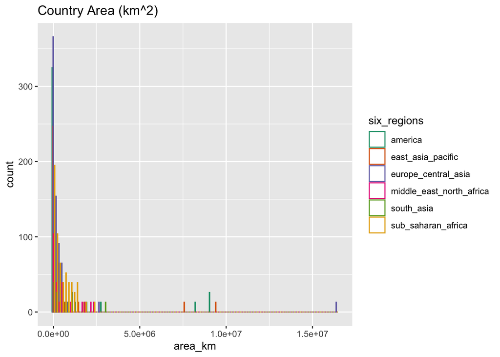

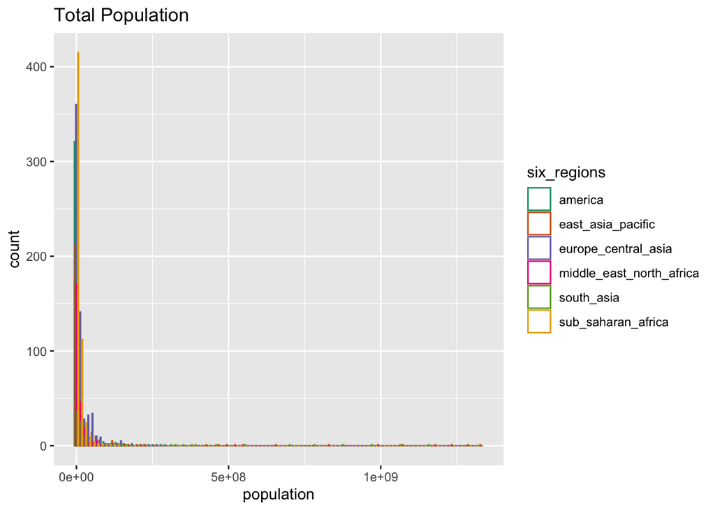

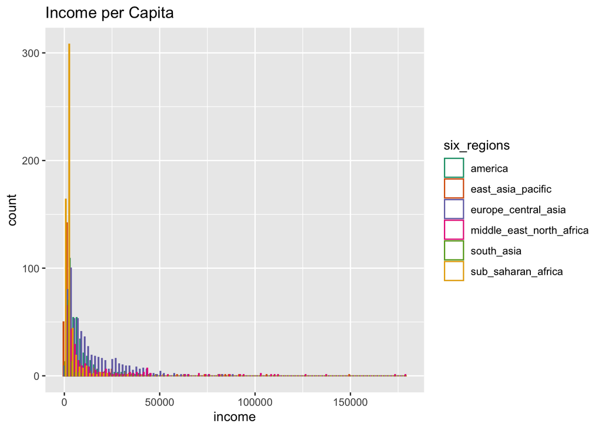

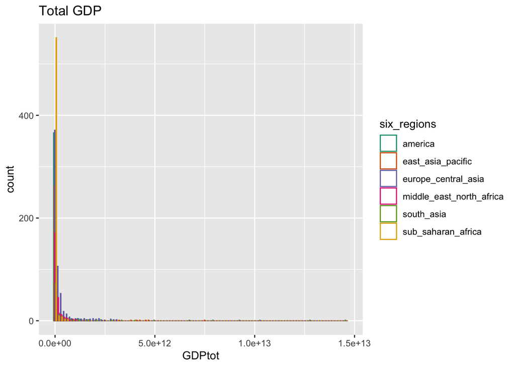

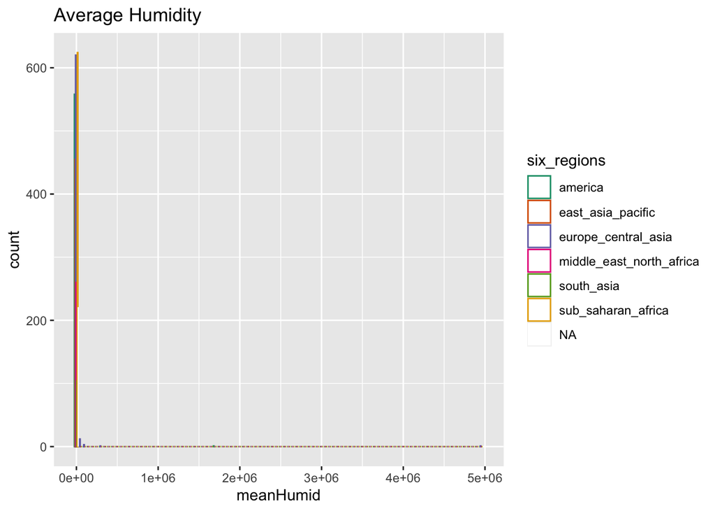

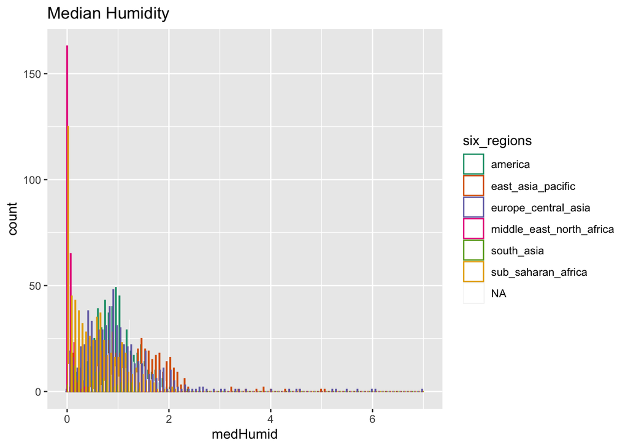

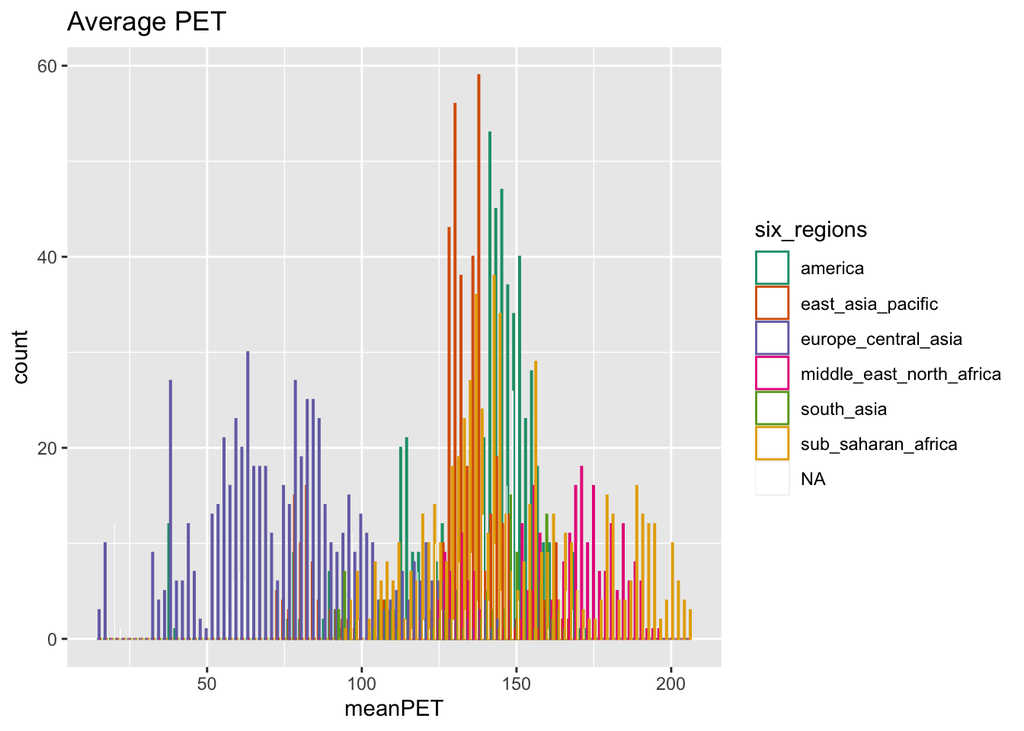

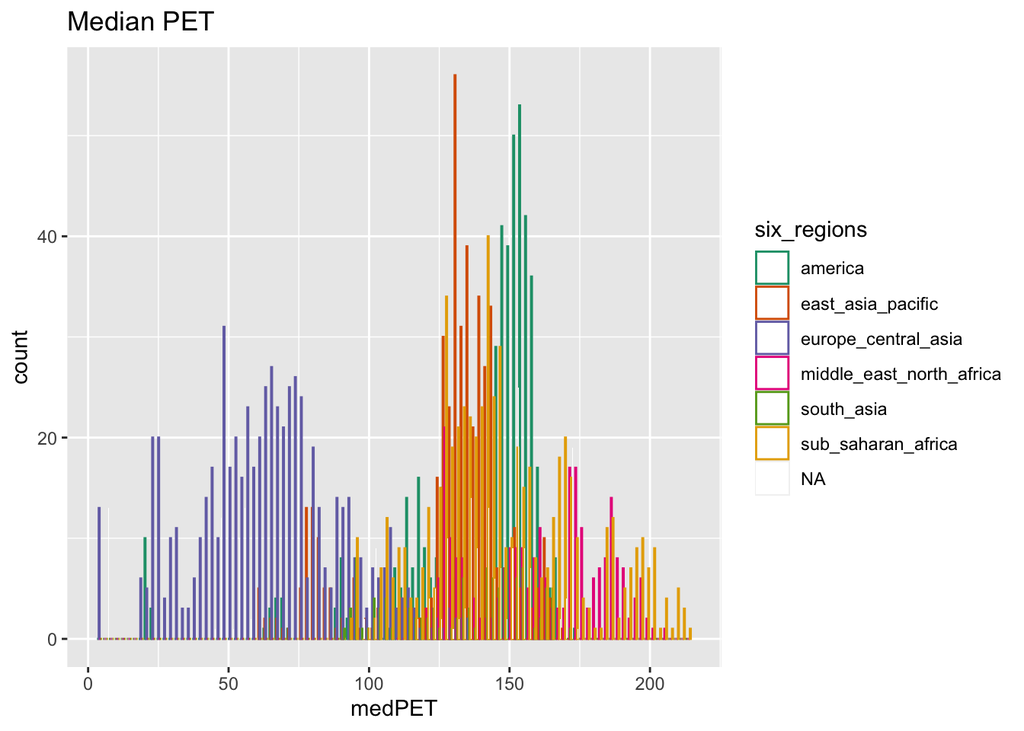

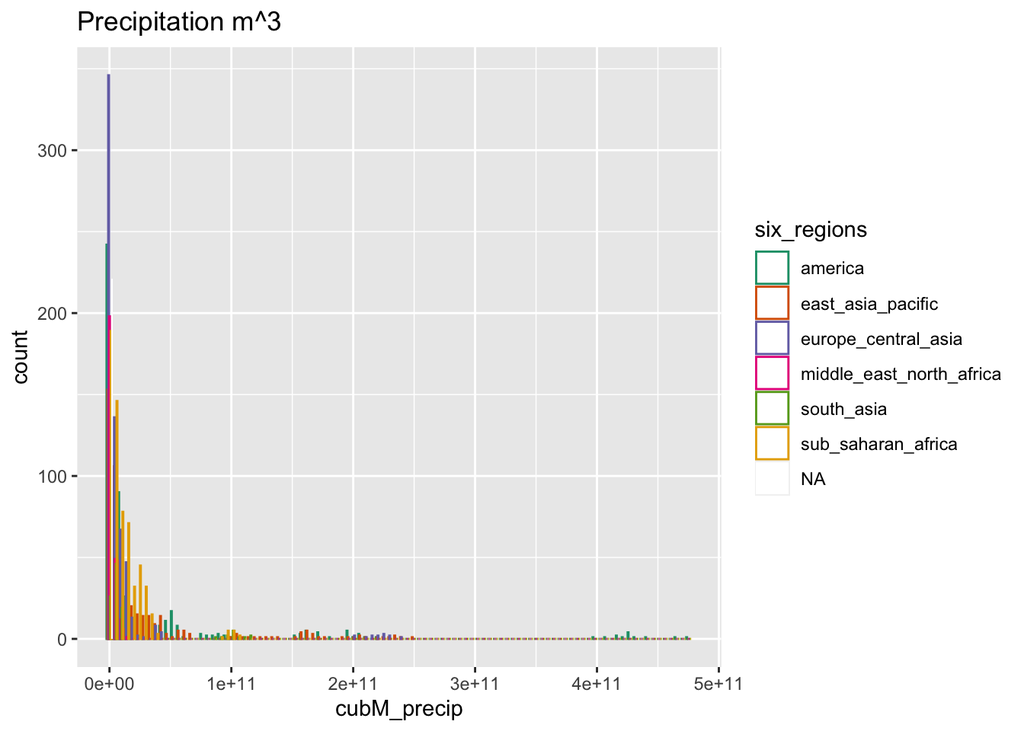

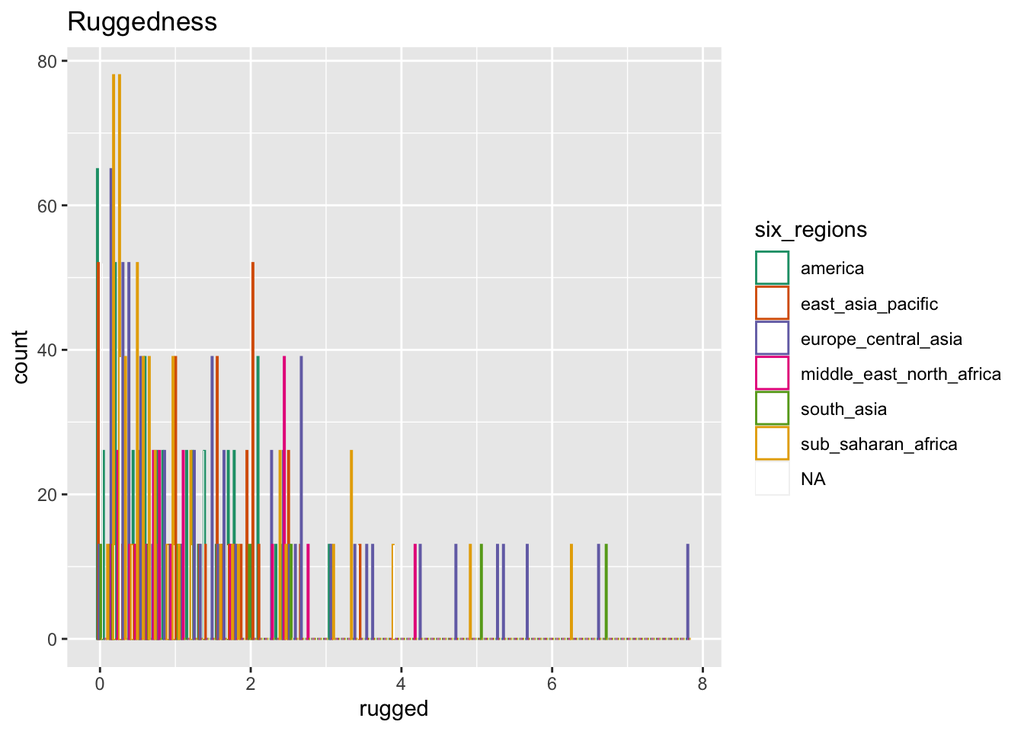